# [Gina Donation Q3 2017](https://ivizri.com/posts/2017/12/gina-q3/)

Created by [SmirkyGraphs](http://smirkygraphs.github.io/). Code: [GitHub](https://github.com/SmirkyGraphs/Python-Notebooks). Source: [BOE](http://ricampaignfinance.com/ExportDocs/6965-RICF2-160792-43966812-d159-4dac-b269-a3bef8d5708b.pdf).

# Gina Donation Q3 2017

## Index

- Breakdown
- Data Importing & Exploring
- When Donations Occured
- What Was Donated
- Where Donations Came From
- Where RI Donations Came From
- In State vs. Out of State
- Where People Worked
- Who Donated
- Donations 1k and Over
- When Out of State passes In State
- Top 4 Most Frequent Donations

## Breakdown

### General Info

$525,881.75 was raised from 992 contributions from 29 different states

### When Donations Occured

- More donations later in the quarter 55% of the people donated in September
- Only 14% of donations were in the first month of the quarter
- Most of the money was raised outside of weekends, Sunday being the lowest and Tuesday being the highest

### What Was Donated

- 53% (525) were paid by Credit/Debit
- 45% (448) were paid by Check
- 992 donations from 904 doners
- 525881.75 was raised
- Average was 530
- Highest was 1174.25, lowest was 1
- Top 5 most frequent in order were: 1000, 500, 250, 25, 10

### Where Donations Came From

- 29 diffrent States
- 225 different Cities
- Top 5 States in order by value: RI, NY, MA, CT, CO
- Top 5 Cities in order by value: Providence, New York, Barrington, Jamestown, Denver

### Where RI Donations Came From

This looks specifically at donations where the person was living in Rhode Island

- 600 donations from RI
- Donations from 36 of the 39 municipalities in RI
- Top 5 cities/towns in order: Providence, Barrington, Jamestown, East Greenwich, Cranston
- Providence made up 29% of the doners from RI
- Providence made up 29% of the total donated from RI
- Counties in order by number of doners: Providence, Washington, Newport, Kent, Bristol
- Counties in order by sum donated: Providence, Newport, Washington, Bristol, Kent

### In State vs. Out of State

Comparing donations based on whether they live in RI or not

- 60% (600) of donations were from Rhode Island
- 40% (392) of donations were from another state
- 47% (248681.22) of money donated was from Rhode Islanders
- 53% (277200.53) of money donated was from out of state
- Average in state 414
- Average out of state 707

### Donations 1k and Over

In state 37% out of state 63%

## Data Importing & Exploring

```python
# For data
import pandas as pd
from pandas import Series,DataFrame
import numpy as np

# For visualization
import matplotlib.pyplot as plt
import seaborn as sns
sns.set_style('darkgrid')
%matplotlib inline
sns.set()
import datetime

my_color = sns.color_palette()
```

```python
# loading the data
df = pd.read_csv("gina.csv", parse_dates=['receipt_dt'])
# removing personal address
df = df.drop(['address'], axis=1)
```

```python
# Preview
df.head()
```

|  | contbr_nm | first_nm | last_nm | tran_type | contb_type | receipt_dt | contb_amt | city | state | zip | employer | employ_address | employ_city | employ_state | employ_zip | weekday |
| --- | --- | --- | --- | --- | --- | --- | --- | --- | --- | --- | --- | --- | --- | --- | --- | --- |
| 0 | Ingrid Ardaya | Ingrid | Ardaya | Credit/Debit | Individual | 2017-07-01 | 5.0 | Providence | RI | 2906 | Disabled | 11 North Avenue | Providence | RI | 2906 | Saturday |
| 1 | Ingrid Ardaya | Ingrid | Ardaya | Credit/Debit | Individual | 2017-07-01 | 5.0 | Providence | RI | 2906 | Disabled | 11 North Avenue | Providence | RI | 2906 | Saturday |
| 2 | Edna Panaggio | Edna | Panaggio | Credit/Debit | Individual | 2017-07-01 | 5.0 | Cranston | RI | 02920-4529 | Homemaker | 200 Hoffman Ave | Cranston | RI | 02920-4529 | Saturday |
| 3 | Eve Savitzky | Eve | Savitzky | Credit/Debit | Individual | 2017-07-01 | 25.0 | Providence | RI | 2906 | Homemaker | 21 Lincoln Ave | Providence | RI | 2906 | Saturday |
| 4 | Anna Siegler | Anna | Siegler | Credit/Debit | Individual | 2017-07-02 | 50.0 | Chicago | IL | 60637 | Retired | 5715 S. Kenwood Ave, Apt 4N | Chicago | IL | 60637 | Sunday |

```python
df.info()
```

```
<class 'pandas.core.frame.DataFrame'>
RangeIndex: 992 entries, 0 to 991
Data columns (total 16 columns):
contbr_nm         992 non-null object
first_nm          971 non-null object
last_nm           971 non-null object
tran_type         992 non-null object
contb_type        992 non-null object
receipt_dt        992 non-null datetime64[ns]
contb_amt         992 non-null float64
city              991 non-null object
state             991 non-null object
zip               988 non-null object
employer          965 non-null object
employ_address    930 non-null object
employ_city       931 non-null object
employ_state      931 non-null object
employ_zip        916 non-null object
weekday           992 non-null object
dtypes: datetime64[ns](1), float64(1), object(14)
memory usage: 124.1+ KB
```

```python
df.shape
```

```
(992, 16)
```

```python
df.contb_amt.sum()
```

```
525881.75
```

There are 992 Donations in Q3 making a total of $525,881.75  
Those missing First/Last name are PAC's/Party donations

## When Donations Occured

lets start by how much was raised each day

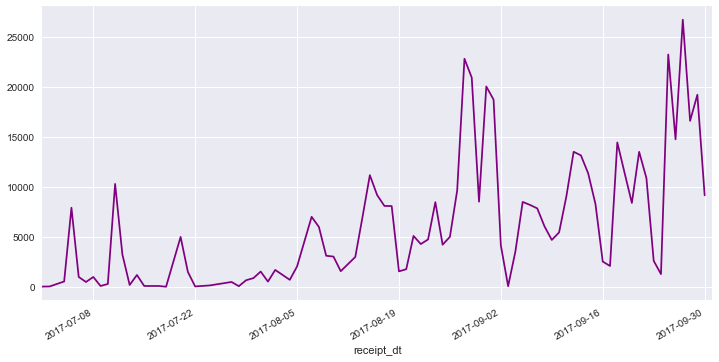

```python
date_df = df.groupby(['receipt_dt'],as_index=False).sum()
date_df.plot('receipt_dt','contb_amt',figsize=(12,6),marker='', legend=False,
             linestyle='-',color='purple', xlim=('2017-07-01','2017-10-01'))
```

```python
# Top 5 Days
date_df.sort_values(by='contb_amt',ascending=False).head()
```

|  | receipt_dt | contb_amt |
| --- | --- | --- |
| 79 | 2017-09-27 | 26710.0 |
| 77 | 2017-09-25 | 23230.0 |
| 49 | 2017-08-28 | 22805.0 |
| 50 | 2017-08-29 | 20925.0 |
| 52 | 2017-08-31 | 20032.6 |

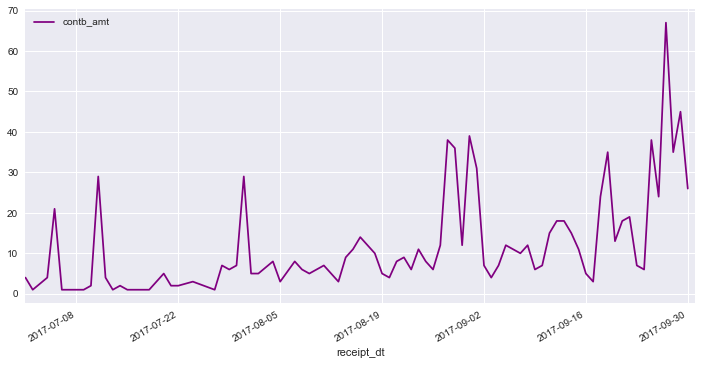

```python
count_df = df.groupby(['receipt_dt'],as_index=False).count()
count_df.plot('receipt_dt','contb_amt',figsize=(12,6),marker='',linestyle='-',color='purple', xlim=('2017-07-01','2017-10-01'))
```

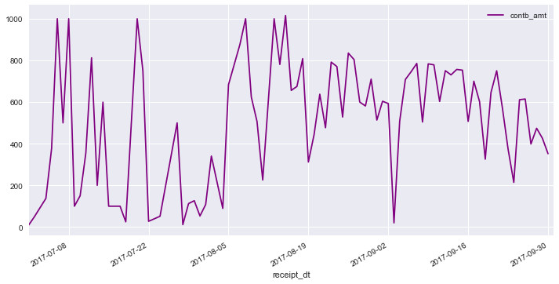

```python
mean_df = df.groupby(['receipt_dt'],as_index=False).mean()
mean_df.plot('receipt_dt','contb_amt',figsize=(12,6),marker='',linestyle='-',color='purple', xlim=('2017-07-01','2017-10-01'))
```

```python
weekday_df = df
weekday_df['weekday'] = pd.Categorical(weekday_df['weekday'],
        categories=['Monday','Tuesday','Wednesday','Thursday',
                    'Friday','Saturday', 'Sunday'], ordered=True)
```

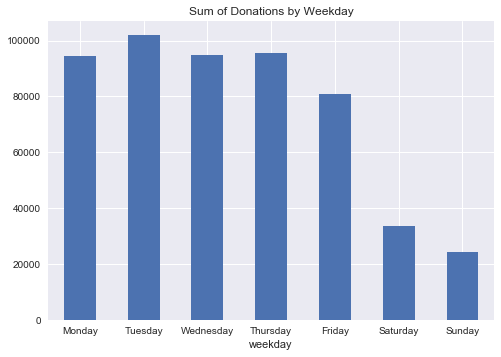

```python
weekday_df_sum = weekday_df.pivot_table(index=weekday_df['weekday'], values='contb_amt',
                 aggfunc='sum').plot(kind='bar',rot=0,legend=False, title='Sum of Donations by Weekday')
```

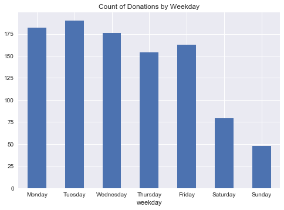

```python
weekday_df_count = weekday_df.pivot_table(index=weekday_df['weekday'], values='contb_amt',
                    aggfunc='count').plot(kind='bar',rot=0, legend=False, title='Count of Donations by Weekday')
```

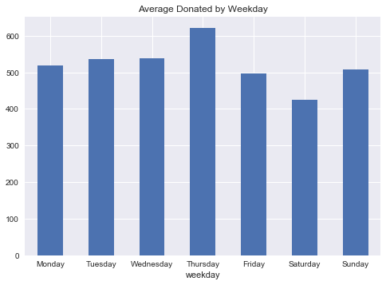

```python
weekday_df_sum = weekday_df.pivot_table(index=weekday_df['weekday'], values='contb_amt',
                    aggfunc='mean').plot(kind='bar',rot=0, legend=False, title='Average Donated by Weekday')
```

```python
df['month'] = df['receipt_dt'].dt.month
```

```python
df['receipt_dt'].dt.month.value_counts()
```

```
9    549
8    306
7    137
Name: receipt_dt, dtype: int64
```

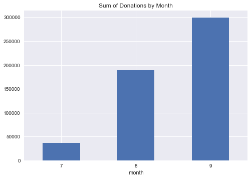

```python
month_sum = df.pivot_table(index=df['month'], values='contb_amt',
                 aggfunc='sum').plot(kind='bar',rot=0,legend=False, title='Sum of Donations by Month')
```

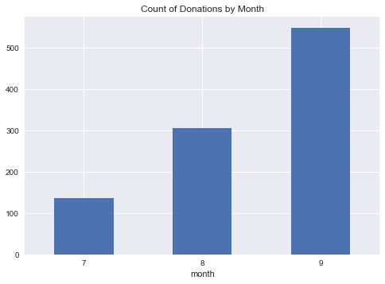

```python
month_sum = df.pivot_table(index=df['month'], values='contb_amt',
                 aggfunc='count').plot(kind='bar',rot=0,legend=False, title='Count of Donations by Month')
```

## What the Donations Were

```python
df.tran_type.value_counts()
```

```
Credit/Debit    525
Check           448
In-Kind          10
Other             9
Name: tran_type, dtype: int64
```

```python
df.tran_type.value_counts(normalize=True)
```

```
Credit/Debit    0.529234
Check           0.451613
In-Kind         0.010081
Other           0.009073
Name: tran_type, dtype: float64
```

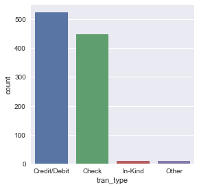

```python
sns.factorplot('tran_type',data=df,kind="count")
```

```python
df['contb_amt'].sum()
```

```
525881.75
```

```python
df['contb_amt'].mode()
```

```
0    1000.0
dtype: float64
```

```python
df['contb_amt'].describe()
```

```
count     992.000000
mean      530.122732
std       410.813074
min         1.000000
25%       100.000000
50%       500.000000
75%      1000.000000
max      1174.250000
Name: contb_amt, dtype: float64
```

I was surprised to see that the average donation was 530 compared to the presidential race when it was only 100  
Lowest donation was 1 and highest was 1174

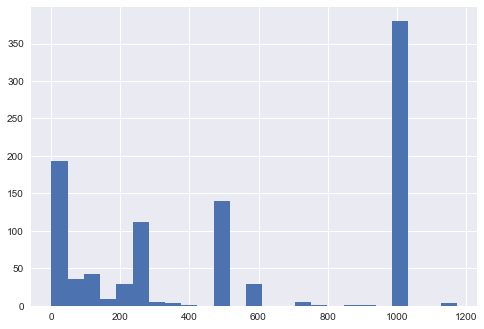

```python
df['contb_amt'].hist(bins=25)
```

```python
df['contb_amt'].value_counts().head()
```

```
1000.0    380
500.0     140
250.0     110
25.0       63
10.0       53
Name: contb_amt, dtype: int64
```

Surprisingly 1000 was the most frequent donation  
The top most frequent donation values were much higher then those during the presidential race

## Where Did Donations Come From?

```python
# 1 State was labeled "Ri" So replace it with RI
df = df.replace(['Ri'],'RI')
```

```python
df.state.nunique()
```

```
29
```

```python
df.state.value_counts()
```

```
RI    600
NY     76
MA     62
CT     43
CO     29
TX     28
DC     19
CA     18
MD     17
FL     15
NJ     15
VA     10
IL      8
PA      7
OR      7
AZ      6
NH      5
WA      4
VT      4
TN      3
MI      3
NM      3
HI      2
SC      2
WI      1
AL      1
GA      1
MO      1
NC      1
Name: state, dtype: int64
```

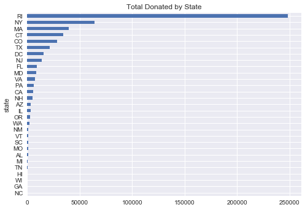

```python
where_sum = df.pivot_table(index=df['state'], values='contb_amt', aggfunc='sum').sort_values(
    by='contb_amt').plot(kind='barh', rot=0, legend=False, title='Total Donated by State')
```

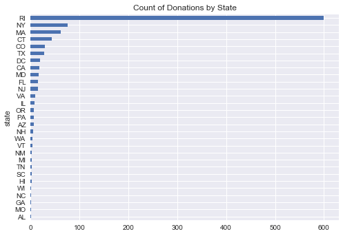

```python
where_count = df.pivot_table(index=df['state'], values='contb_amt', aggfunc='count').sort_values(
    by='contb_amt').plot(kind='barh', rot=0, legend=False, title='Count of Donations by State')
```

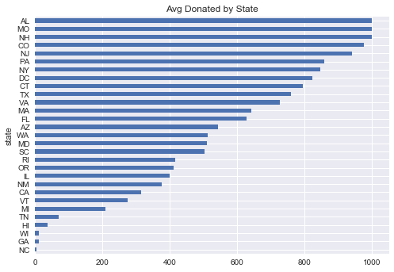

```python
where_avg = df.pivot_table(index=df['state'], values='contb_amt', aggfunc='mean').sort_values(
    by='contb_amt').plot(kind='barh', rot=0, legend=False, title='Avg Donated by State')
```

```python
df.city.nunique()
```

```
225
```

```python
# Top 5 Cities
city_df = df.pivot_table('contb_amt',index='city',aggfunc='sum')
city_df = city_df.sort_values(by="contb_amt",ascending=False)

city_df.head()
```

| city | contb_amt |
| --- | --- |
| Providence | 62241.43 |
| New York | 44350.00 |
| Barrington | 22470.00 |
| Jamestown | 21775.00 |
| Denver | 21000.00 |

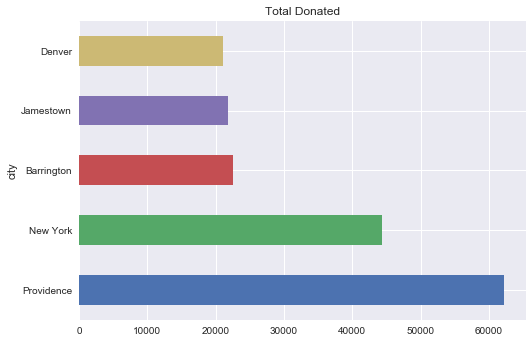

```python
city_sum = df.pivot_table(index=df['city'], values='contb_amt', aggfunc='sum').sort_values(
    by='contb_amt').nlargest(5, 'contb_amt').plot(kind='barh', color=my_color, legend=False, title='Total Donated')
```

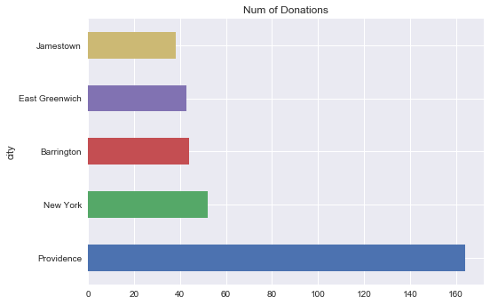

```python
city_count = df.pivot_table(index=df['city'], values='contb_amt', aggfunc='count').sort_values(
    by='contb_amt').nlargest(5, 'contb_amt').plot(kind='barh', color=my_color, legend=False, title='Num of Donations')
```

## RI Donations

```python
# Just donations from RI
RI_df = df[df.state == 'RI']
```

```python
RI_df.city.unique()
```

```
array(['Providence', 'Cranston', 'Lincoln', 'Barrington', 'Cumberland',
       'Pascoag', 'Smithfield', 'East Greenwich', 'Johnston', 'Pawtucket',
       'Jamestown', 'Wakefield', 'Saunderstown', 'Portsmouth', 'Newport',
       'West Warwick', 'North Kingstown', 'Warwick', 'PROVIDENCE',
       'Tiverton', 'Harmony', 'Bristol', 'Warren', 'West Greenwich',
       'Westerly', 'Riverside', 'N Kingstown', 'Rumford', 'Narragansett',
       'Exeter', 'Coventry', 'East Providence', 'South Kingstown',
       'North Providence', 'Middletown', 'Charlestown', 'North Kingstownq',
       'Foster', 'Block Island', 'Scituate', 'Little Compton',
       'New Shoreham', 'Peace Dale', 'Central Falls', 'North Scituate',
       'Glocester', 'E Greenwich', 'Woonsocket', 'Albion', 'Kingston'], dtype=object)
```

```python
# Connect small towns to the City/Town they're part of
RI_df = RI_df.replace(['Pascoag'],'Burrillville')
RI_df = RI_df.replace(['Wakefield','Kingston','Peace Dale'],'South Kingstown')
RI_df = RI_df.replace(['Saunderstown','N Kingstown','North Kingstownq'],'North Kingstown')
RI_df = RI_df.replace(['E Greenwich'],'East Greenwich')
RI_df = RI_df.replace(['PROVIDENCE'],'Providence')
RI_df = RI_df.replace(['Harmony'],'Glocester')
RI_df = RI_df.replace(['Riverside','Rumford'],'East Providence')
RI_df = RI_df.replace(['Block Island'],'New Shoreham')
RI_df = RI_df.replace(['North Scituate'],'Scituate')
RI_df = RI_df.replace(['Albion'],'Lincoln')
```

```python
RI_df.city.nunique()
```

```
36
```

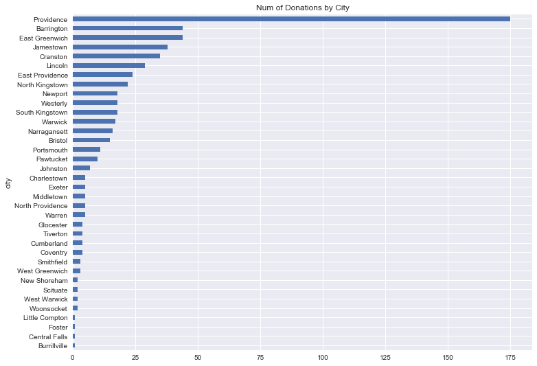

```python
ri_city = df.pivot_table(index=RI_df['city'], values='contb_amt', aggfunc='count').sort_values(ascending=True,
    by='contb_amt').plot(kind='barh', figsize=(12,9), legend=False, title='Num of Donations by City')
```

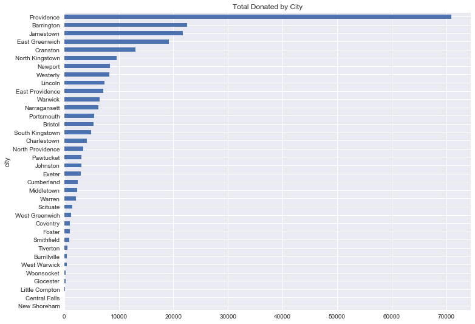

```python
ri_city = df.pivot_table(index=RI_df['city'], values='contb_amt', aggfunc='sum').sort_values(ascending=True,
    by='contb_amt').plot(kind='barh', figsize=(12,9), legend=False, title='Total Donated by City')
```

```python
RI_df['city'].value_counts().sum()
```

```
600
```

```python
RI_df['city'].value_counts().head()
```

```
Providence        175
East Greenwich     44
Barrington         44
Jamestown          38
Cranston           35
Name: city, dtype: int64
```

```python
RI_Sum = RI_df.pivot_table('contb_amt',index='city',aggfunc='sum')
RI_Sum = RI_Sum.sort_values(by='contb_amt', ascending=False)

RI_Sum.sum()
```

```
contb_amt    248681.22
dtype: float64
```

```python
RI_Sum
```

| city | contb_amt |
| --- | --- |
| Providence | 70988.43 |
| Barrington | 22470.00 |
| Jamestown | 21775.00 |
| East Greenwich | 19170.00 |
| Cranston | 13061.00 |
| North Kingstown | 9585.00 |
| Newport | 8390.00 |
| Westerly | 8305.00 |
| Lincoln | 7360.00 |
| East Providence | 7170.79 |
| Warwick | 6490.00 |
| Narragansett | 6310.00 |
| Portsmouth | 5505.00 |
| Bristol | 5380.00 |
| South Kingstown | 4935.00 |
| Charlestown | 4100.00 |
| North Providence | 3525.00 |
| Pawtucket | 3130.00 |
| Johnston | 3125.00 |
| Exeter | 3035.00 |
| Cumberland | 2500.00 |
| Middletown | 2375.00 |
| Warren | 2100.00 |
| Scituate | 1500.00 |
| West Greenwich | 1200.00 |
| Coventry | 1060.00 |
| Foster | 1000.00 |
| Smithfield | 950.00 |
| Tiverton | 550.00 |
| West Warwick | 500.00 |
| Burrillville | 500.00 |
| Woonsocket | 275.00 |
| Glocester | 225.00 |
| Little Compton | 100.00 |
| Central Falls | 25.00 |
| New Shoreham | 11.00 |

```python
# dictionary of RI Counties
county_map = {'Barrington': 'BRISTOL',
            'Bristol': 'BRISTOL',
            'Burrillville': 'PROVIDENCE',
            'Central Falls': 'PROVIDENCE',
            'Charlestown': 'WASHINGTON',
            'Coventry': 'KENT',
            'Cranston': 'PROVIDENCE',
            'Cumberland': 'PROVIDENCE',
            'East Greenwich': 'KENT',
            'East Providence': 'PROVIDENCE',
            'Exeter': 'WASHINGTON',
            'Foster': 'PROVIDENCE',
            'Glocester': 'PROVIDENCE',
            'Hopkinton': 'WASHINGTON',
            'Jamestown': 'NEWPORT',
            'Johnston': 'PROVIDENCE',
            'Lincoln': 'PROVIDENCE',
            'Little Compton': 'NEWPORT',
            'Middletown': 'NEWPORT',
            'Narragansett': 'WASHINGTON',
            'Newport': 'NEWPORT',
            'New Shoreham': 'WASHINGTON',
            'North Kingstown': 'WASHINGTON',
            'North Providence': 'PROVIDENCE',
            'North Smithfield': 'PROVIDENCE',
            'Pawtucket': 'PROVIDENCE',
            'Portsmouth': 'NEWPORT',
            'Providence': 'PROVIDENCE',
            'Richmond': 'WASHINGTON',
            'Scituate': 'PROVIDENCE',
            'Smithfield': 'PROVIDENCE',
            'South Kingstown': 'WASHINGTON',
            'Tiverton': 'NEWPORT',
            'Warren': 'BRISTOL',
            'Warwick': 'KENT',
            'Westerly': 'WASHINGTON',
            'West Greenwich': 'KENT',
            'West Warwick': 'KENT',
            'Woonsocket': 'PROVIDENCE'}

# creating a party column and mapping party to canidate
RI_df['County'] = RI_df.city.map(county_map)
```

```python
RI_df['County'].value_counts()
```

```
PROVIDENCE    303
WASHINGTON     86
NEWPORT        77
KENT           70
BRISTOL        64
Name: County, dtype: int64
```

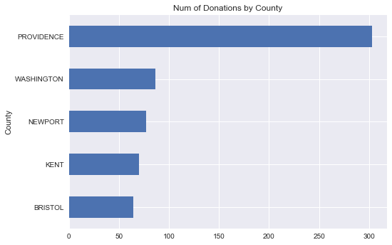

```python
ri_city = df.pivot_table(index=RI_df['County'], values='contb_amt', aggfunc='count').sort_values(ascending=True,
    by='contb_amt').plot(kind='barh', legend=False, title='Num of Donations by County')
```

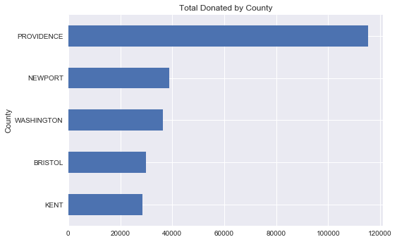

```python
ri_city = df.pivot_table(index=RI_df['County'], values='contb_amt', aggfunc='sum').sort_values(ascending=True,
    by='contb_amt').plot(kind='barh', legend=False, title='Total Donated by County')
```

## In State vs. Out of State

```python
def in_ri(state):
    if state == 'RI':
        return 'in state'
    else:
        return 'out of state'
```

```python
df['lives'] = df['state'].apply(in_ri)
```

```python
df_lives = df
```

```python
df['lives'] = pd.Categorical(df['lives'], categories=['in state','out of state'], ordered=True)
```

```python
df.head()
```

|  | contbr_nm | first_nm | last_nm | tran_type | contb_type | receipt_dt | contb_amt | city | state | zip | employer | employ_address | employ_city | employ_state | employ_zip | weekday | month | lives |
| --- | --- | --- | --- | --- | --- | --- | --- | --- | --- | --- | --- | --- | --- | --- | --- | --- | --- | --- |
| 0 | Ingrid Ardaya | Ingrid | Ardaya | Credit/Debit | Individual | 2017-07-01 | 5.0 | Providence | RI | 2906 | Disabled | 11 North Avenue | Providence | RI | 2906 | Saturday | 7 | in state |
| 1 | Ingrid Ardaya | Ingrid | Ardaya | Credit/Debit | Individual | 2017-07-01 | 5.0 | Providence | RI | 2906 | Disabled | 11 North Avenue | Providence | RI | 2906 | Saturday | 7 | in state |
| 2 | Edna Panaggio | Edna | Panaggio | Credit/Debit | Individual | 2017-07-01 | 5.0 | Cranston | RI | 02920-4529 | Homemaker | 200 Hoffman Ave | Cranston | RI | 02920-4529 | Saturday | 7 | in state |
| 3 | Eve Savitzky | Eve | Savitzky | Credit/Debit | Individual | 2017-07-01 | 25.0 | Providence | RI | 2906 | Homemaker | 21 Lincoln Ave | Providence | RI | 2906 | Saturday | 7 | in state |
| 4 | Anna Siegler | Anna | Siegler | Credit/Debit | Individual | 2017-07-02 | 50.0 | Chicago | IL | 60637 | Retired | 5715 S. Kenwood Ave, Apt 4N | Chicago | IL | 60637 | Sunday | 7 | out of state |

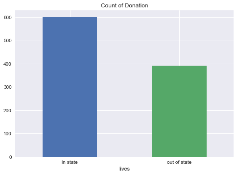

```python
count_df = df.pivot_table(index=df['lives'], values='contb_amt', aggfunc='count').plot(kind='bar',
                        rot=0, color=my_color, legend=False, title='Count of Donation')
```

```python
print(df['lives'].value_counts())
(df['lives'].value_counts(normalize=True))
```

```
in state        600
out of state    392
Name: lives, dtype: int64
```

```
in state        0.604839
out of state    0.395161
Name: lives, dtype: float64
```

60% (600) Were from Rhode Island  
40% (392) Were from another state

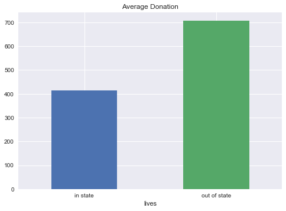

```python
mean_df = df.pivot_table(index=df['lives'], values='contb_amt', aggfunc='mean').plot(kind='bar',
                        rot=0, color=my_color, legend=False, title='Average Donation')
```

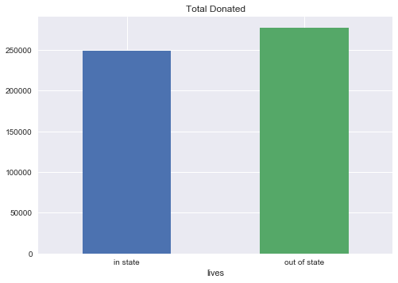

```python
sum_df = df.pivot_table(index=df['lives'], values='contb_amt', aggfunc='sum').plot(kind='bar',
                        rot=0, color=my_color, legend=False, title='Total Donated')
```

```python
percent_df = df.pivot_table(index=df['lives'], values='contb_amt', aggfunc='sum')
```

```python
total_sum = percent_df.contb_amt.sum()
df['lives'] = df['state'].apply(in_ri)
percent_df['Percent'] = percent_df['contb_amt'] / total_sum
```

```python
percent_df.head()
```

| lives | contb_amt | Percent |
| --- | --- | --- |
| in state | 248681.22 | 0.472884 |
| out of state | 277200.53 | 0.527116 |

```python
mean_df = df.pivot_table(index=df['lives'], values='contb_amt', aggfunc='mean')
mean_df.head()
```

| lives | contb_amt |
| --- | --- |
| in state | 414.468700 |
| out of state | 707.144209 |

## Where People Worked

```python
employer_df = df.pivot_table('contb_amt',index='employer',aggfunc='sum')

# Combining Electric Boat & Genral Dynamics
employer_df.loc['General Dynamics'] = employer_df.loc['Electric Boat Corporation'] + employer_df.loc['General Dynamics']
employer_df.drop('Electric Boat Corporation',inplace=True)

employer_df = employer_df.sort_values(by = 'contb_amt',ascending=True)
```

```python
employer_df.count()
```

```
contb_amt    489
dtype: int64
```

Donations from people who worked at 489 different companies, lets narrow it down to companies over $1000

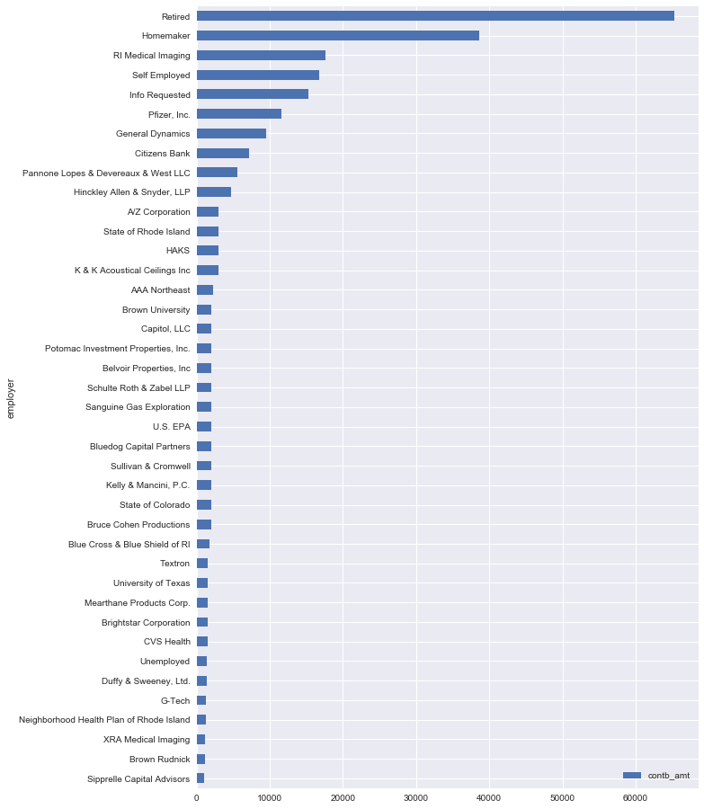

```python
# Getting all employer records over $1000

employer_df = employer_df[employer_df['contb_amt'] > 1000]
employer_df.plot(kind='barh',figsize=(10,16))
```

```python
# Graphing Only Companies
employer_df.drop('Homemaker',inplace=True)
employer_df.drop('Retired',inplace=True)
employer_df.drop('Self Employed',inplace=True)
employer_df.drop('Info Requested',inplace=True)

employer_df = employer_df.sort_values(by = 'contb_amt',ascending=True)
```

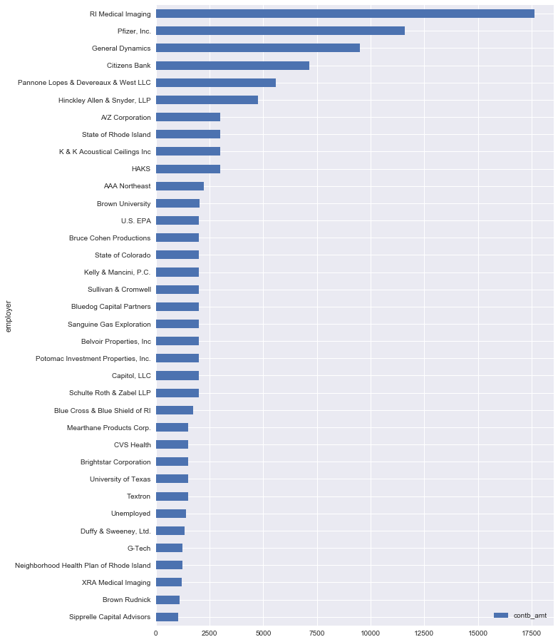

```python
# Getting all employer records over $1000
employer_df = employer_df[employer_df['contb_amt'] > 1000]
employer_df.plot(kind='barh',figsize=(10,16))
```

```python
def in_ri(employ_state):
    if employ_state == 'RI':
        return 'in state'
    else:
        return 'out of state'
```

```python
df['works'] = df['employ_state'].apply(in_ri)
```

```python
df.head()
```

|  | contbr_nm | first_nm | last_nm | tran_type | contb_type | receipt_dt | contb_amt | city | state | zip | employer | employ_address | employ_city | employ_state | employ_zip | weekday | month | lives | works |
| --- | --- | --- | --- | --- | --- | --- | --- | --- | --- | --- | --- | --- | --- | --- | --- | --- | --- | --- | --- |
| 0 | Ingrid Ardaya | Ingrid | Ardaya | Credit/Debit | Individual | 2017-07-01 | 5.0 | Providence | RI | 2906 | Disabled | 11 North Avenue | Providence | RI | 2906 | Saturday | 7 | in state | in state |
| 1 | Ingrid Ardaya | Ingrid | Ardaya | Credit/Debit | Individual | 2017-07-01 | 5.0 | Providence | RI | 2906 | Disabled | 11 North Avenue | Providence | RI | 2906 | Saturday | 7 | in state | in state |
| 2 | Edna Panaggio | Edna | Panaggio | Credit/Debit | Individual | 2017-07-01 | 5.0 | Cranston | RI | 02920-4529 | Homemaker | 200 Hoffman Ave | Cranston | RI | 02920-4529 | Saturday | 7 | in state | in state |
| 3 | Eve Savitzky | Eve | Savitzky | Credit/Debit | Individual | 2017-07-01 | 25.0 | Providence | RI | 2906 | Homemaker | 21 Lincoln Ave | Providence | RI | 2906 | Saturday | 7 | in state | in state |
| 4 | Anna Siegler | Anna | Siegler | Credit/Debit | Individual | 2017-07-02 | 50.0 | Chicago | IL | 60637 | Retired | 5715 S. Kenwood Ave, Apt 4N | Chicago | IL | 60637 | Sunday | 7 | out of state | out of state |

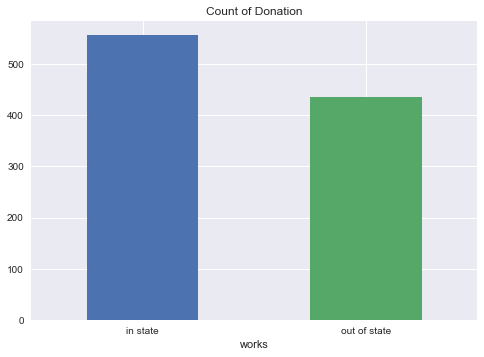

```python
# Including Extras
count_df = df.pivot_table(index=df['works'], values='contb_amt', aggfunc='count').plot(kind='bar',
                        rot=0, color=my_color, legend=False, title='Count of Donation')
```

```python
df['works'].value_counts()
```

```
in state        557
out of state    435
Name: works, dtype: int64
```

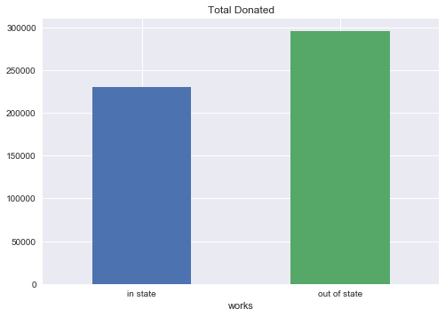

```python
# Including Extras
count_df = df.pivot_table(index=df['works'], values='contb_amt', aggfunc='sum').plot(kind='bar',
                        rot=0, color=my_color, legend=False, title='Total Donated')
```

```python
# Including Extras getting % of sum
percent_df = df.pivot_table(index=df['works'], values='contb_amt', aggfunc='sum')

total_sum = df.contb_amt.sum()
percent_df['Percent'] = percent_df['contb_amt'] / total_sum

percent_df.head()
```

| works | contb_amt | Percent |
| --- | --- | --- |
| in state | 230305.00 | 0.437941 |
| out of state | 295576.75 | 0.562059 |

```python
# Removing Extras
emp_df = df[df.employer != 'Homemaker']
emp_df = df[df.employer != 'Retired']
emp_df = df[df.employer != 'Self Employed']
emp_df = df[df.employer != 'Info Requested']
emp_df = df[df.employer != 'Disabled']
```

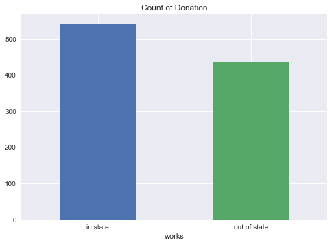

```python
# Extras Removed
count_df = emp_df.pivot_table(index=df['works'], values='contb_amt', aggfunc='count').plot(kind='bar',
                        rot=0, color=my_color, legend=False, title='Count of Donation')
```

```python
emp_df['works'].value_counts()
```

```
in state        541
out of state    434
Name: works, dtype: int64
```

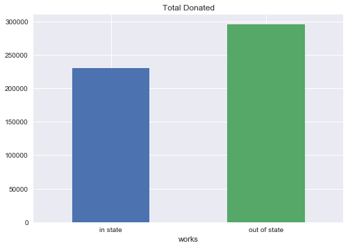

```python
# Extras Removed
count_df = emp_df.pivot_table(index=df['works'], values='contb_amt', aggfunc='sum').plot(kind='bar',
                        rot=0, color=my_color, legend=False, title='Total Donated')
```

## Who Donated

```python
df.contbr_nm.nunique()
```

```
904
```

```python
df.first_nm.value_counts().head()
```

```
David      31
Michael    25
Susan      20
William    19
Robert     19
Name: first_nm, dtype: int64
```

```python
df.last_nm.value_counts().head()
```

```
Ardaya        16
Kelly          9
Richardson     6
Watson         5
Pande          5
Name: last_nm, dtype: int64
```

```python
df.contb_type.value_counts()
```

```
Individual              966
Interest Received         8
PAC                       6
In-Kind - Individual      5
In-Kind - Party           4
Refund/Rebate             1
In-Kind - PAC             1
Party                     1
Name: contb_type, dtype: int64
```

```python
df.contb_type.value_counts(normalize=True)
```

```
Individual              0.973790
Interest Received       0.008065
PAC                     0.006048
In-Kind - Individual    0.005040
In-Kind - Party         0.004032
Refund/Rebate           0.001008
In-Kind - PAC           0.001008
Party                   0.001008
Name: contb_type, dtype: float64
```

## Donations 1k and Over

```python
don_1k = df[df['contb_amt'] >= 1000]
```

```python
don_1k = df[(df['contb_amt'] >= 1000)]
```

```python
don_1k.lives.value_counts(normalize=True)
```

```
out of state    0.630208
in state        0.369792
Name: lives, dtype: float64
```

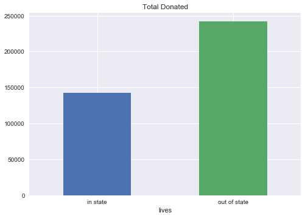

```python
sum_df = don_1k.pivot_table(index=df_lives['lives'], values='contb_amt', aggfunc='sum').plot(kind='bar',
                        rot=0, color=my_color, legend=False, title='Total Donated')
```

## When Out of State Passes In State

```python
don_df_100 = df[df.contb_amt <= 100]
don_df_250 = df[df.contb_amt <= 250]
don_df_350 = df[df.contb_amt <= 350]
don_df_500 = df[df.contb_amt <= 500]
don_df_750 = df[df.contb_amt <= 750]
don_df_1000 = df[df.contb_amt <= 1000]
```

```python
# Concatinating the datasets together
frames = [don_df_100, don_df_250, don_df_350, don_df_500, don_df_750, don_df_1000]

don_concat = pd.concat(frames, keys=['100', '250', '350', '500', '750', '1000'])

# resetting the index and dropping the columns we don't need
don_concat = don_concat.reset_index()
```

```python
# Pivoting by the amt ranges
don_concat = don_concat.pivot_table('contb_amt',index='level_0',columns = 'lives',aggfunc='sum')
```

```python
new_index= ['100', '250', '350', '500', '750', '1000']
don_concat = don_concat.reindex(new_index)
don_concat.head()
```

| lives level_0 | in state | out of state |
| --- | --- | --- |
| 100 | 5683.68 | 2901.53 |
| 250 | 33314.22 | 10850.53 |
| 350 | 34914.22 | 11800.53 |
| 500 | 86789.22 | 30700.53 |
| 750 | 103444.22 | 35200.53 |

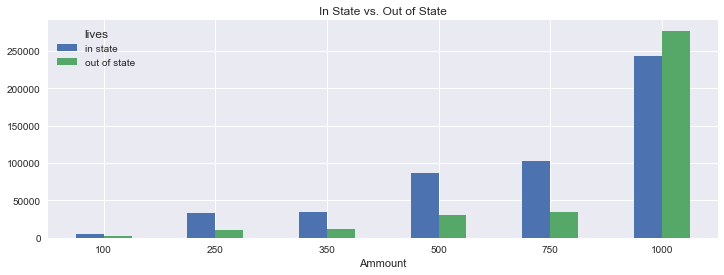

```python
don_concat[['in state','out of state']].plot(kind='bar',figsize=(12,4))
plt.xlabel('Ammount')
locs, labels = plt.xticks()
plt.setp(labels, rotation=360)
plt.title('In State vs. Out of State')
```

## Top 4 Most Frequent Donations In State vs Out of State

```python
# Top 4 Donated Values
don_25 = df[df.contb_amt == 25]
don_250 = df[df.contb_amt == 250]
don_500 = df[df.contb_amt == 500]
don_1000 = df[df.contb_amt == 1000]
```

```python
# Concatinating the datasets together
frames = [don_25, don_250, don_500, don_1000]

don_concat = pd.concat(frames, keys=['25', '250', '500', '1000'])
#resetting the index and dropping the columns we don't need
don_concat = don_concat.reset_index()
```

```python
# Pivoting by the amt ranges
don_concat = don_concat.pivot_table('contb_amt',index='level_0',columns = 'lives',aggfunc='sum')
```

```python
don_concat.head()
```

| lives level_0 | in state | out of state |
| --- | --- | --- |
| 1000 | 138000.0 | 242000.0 |
| 25 | 1275.0 | 300.0 |
| 250 | 22000.0 | 5500.0 |
| 500 | 51500.0 | 18500.0 |

```python
new_index= ['25', '250', '500', '1000']
don_concat = don_concat.reindex(new_index)
don_concat.head()
```

| lives level_0 | in state | out of state |
| --- | --- | --- |
| 25 | 1275.0 | 300.0 |
| 250 | 22000.0 | 5500.0 |
| 500 | 51500.0 | 18500.0 |
| 1000 | 138000.0 | 242000.0 |

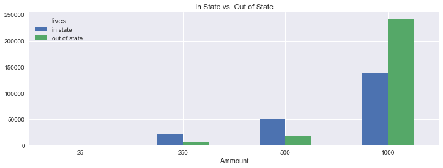

```python
don_concat[['in state','out of state']].plot(kind='bar',figsize=(12,4))
plt.xlabel('Ammount')
locs, labels = plt.xticks()
plt.setp(labels, rotation=360)
plt.title('In State vs. Out of State')
```